# CSSS 510: Lab 3

Logistic Regression

2017-10-13

# 0. Agenda

1. Deriving a likelihood function for the logistic regression model
2. Fitting a logit model using $\textsf{optim}()$ and $\textsf{glm}()$
3. Simulating predicted values and confidence intervals
4. Simulating first differences

# 1. Deriving a likelihood function for the logistic regression model

Recall from lecture the logit model:

$$\begin{equation*}
\begin{split}
y_{i} &\sim \text{Bern}(\pi_{i}) \\
\pi_{i} &= \text{logit}^{-1}(\boldsymbol{x}_{i}\boldsymbol{\beta})\\
\pi_{i} &= \frac{\text{exp}(\boldsymbol{x}_{i}\boldsymbol{\beta})}{1+\text{exp}(\boldsymbol{x}_{i}\boldsymbol{\beta})} = \frac{1}{1+\text{exp}(-\boldsymbol{x}_{i}\boldsymbol{\beta})}
\end{split}
\end{equation*}$$

In the simple case, this stems from the latent variable model:

$$y^* = \beta_{0} + \beta_{1}x + \epsilon$$

where the relationship between latent variable $y^*$ and the explanatory variable $x$ is modeled using simple linear regression, and the binary outcome $y$ is a function of the sign of $y^*$:

$$\begin{equation}
y=\begin{cases}
1, & \text{if $y^*>0$}\\
0, & \text{if $y^*\leq0$}
\end{cases}
\end{equation}$$

The logistic regression model is obtained if we assume the errors of this latent variable model follow a standard logistic distribution. Recall that the pdf and cdf of the standard logisitic distribution are as follows:

$$f(t) = \frac{\text{exp}(t)}{(1 + \text{exp}(t))^2}$$
$$F(t) = \frac{\text{exp}(t)}{1+\text{exp}(t)}$$

We therefore have the following:
$$\begin{equation*}
\begin{split}
\text{Pr}(y=1|x) &= \text{Pr}(y^*>0|x)\\
&= \text{Pr}(\beta_{0} + \beta_{1}x + \epsilon>0|x)\\
&= \text{Pr}(\epsilon > -(\beta_{0} + \beta_{1}x))\\
&= \text{Pr}(\epsilon < \beta_{0} + \beta_{1}x)\\
&= F(\beta_{0}^{L}+\beta_{1}^{L}x)
\end{split}
\end{equation*}$$

Since we assume the errors follow a standard logistic distribution, we have

$$\text{Pr}(y=1|x)=F(\beta_{0}^{L}+\beta_{1}^{L}x)=\frac{\text{exp}(\beta^L_0+\beta^L_1x)}{1+\text{exp}(\beta^L_0+\beta^L_1x)}$$
and E$(\epsilon)$=0 and Var$(\epsilon)=\frac{\pi^2}{3}$.

The logit function is the inverse of the logistic function:

$$\text{logit}(p)=\text{log}\frac{p}{1-p}$$
or
$$\text{logit}^{-1}(p)=\frac{\text{exp}(x)}{1+\text{exp}(x)}$$
We therefore have the following
$$\text{Pr}(y=1|x)=\text{logit}^{-1}(\beta_{1}^{L}+\beta_{1}^{L}x)$$
or
$$\text{logit}(\text{Pr}(y=1|x))=\beta_{1}^{L}+\beta_{1}^{L}x$$
or
$$\text{log}\frac{\text{Pr}(y=1|x)}{\text{Pr}(y=0|x)}=\beta_{0}^{L}+\beta_{1}^{L}x.$$
$\newline$

Recall from lecture that a Bernoulli distribution has the following pdf:

$$\begin{equation*}
\begin{split}
\text{Pr}(y_{i}=1|\pi_{i}) &= \pi_{i}^{y_{i}}(1 - \pi_{i})^{1-y_{i}}
\end{split}
\end{equation*}$$

And the likelihood function can be derived from the joint probability:

$$\begin{equation*}
\begin{split}
\mathcal{L}(\boldsymbol{\pi}|\boldsymbol{y}) &\propto \prod^{n}_{i=1}\pi_{i}^{y_{i}}(1-\pi_{i})^{1-y_{i}}\\
\mathcal{L}(\boldsymbol{\beta}|\boldsymbol{y}) &\propto \prod^{n}_{i=1}\bigg(\frac{1}{1+\text{exp}(-\boldsymbol{x}_{i}\boldsymbol{\beta})}\bigg)^{y_i}\bigg(1-\frac{1}{1+\text{exp}(-\boldsymbol{x}_{i}\boldsymbol{\beta})}\bigg)^{1-y_i}\\
\mathcal{L}(\boldsymbol{\beta}|\boldsymbol{y}) &\propto \prod^{n}_{i=1}(1+\text{exp}(-\boldsymbol{x}_{i}\boldsymbol{\beta}))^{-y_{i}}(1+\text{exp}(-\boldsymbol{x}_{i}\boldsymbol{\beta}))^{-(1-y_{i})}\\
\text{log}\mathcal{L}(\boldsymbol{\beta}|\boldsymbol{y}) &\propto \sum^{n}_{i=1} -y_{i}\text{log} (1+\text{exp}(-\boldsymbol{x}_{i}\boldsymbol{\beta}))-(1-y_{i})\text{log}(1+\text{exp}(\boldsymbol{x}_{i}\boldsymbol{\beta}))
\end{split}
\end{equation*}$$

# 2. Fitting a logit model using $\textsf{optim}()$ and $\textsf{glm}()$

```r
rm(list = ls()) # clear up the memory

#install and load the packages needed
#from CRAN: install.packages("MASS", dependencies = TRUE)
library(MASS)
library(RColorBrewer)

#download simcf and tile packages from- http://faculty.washington.edu/cadolph/software
# don't unzip the archive (tar) file
library(simcf)
library(tile)
# Load data
file <- "nes00a.csv"
data <- read.csv(file, header=TRUE)

# attach(data)

# Estimate logit model using optim()
# Construct variables and model objects
y <- data$vote00
x <- cbind(data$age,data$hsdeg,data$coldeg)

# Likelihood function for logit
llk.logit <- function(param,y,x) {
  os <- rep(1,length(x[,1])) # constant
  x <- cbind(os,x) # constant+covariates
  b <- param[ 1 : ncol(x) ]
  # number of parameters to be estimated equals number of columns in x
  # (i.e, one for constant and one for each covariates : total 4)
  xb <- x%*%b
  sum( y*log(1+exp(-xb)) + (1-y)*log(1+exp(xb))) # log-likelihood function for logit model
  # (based on our choice of standard logistic cdf as the systematic component)
               # optim is a minimizer, so use -lnL here
}

# Fit logit model using optim
ls.result <- lm(y~x)  # use ls estimates as starting values (for convenience)
stval <- ls.result$coefficients  # initial guesses
logit.result.opt <- optim(stval,llk.logit,method="BFGS",hessian=T,y=y,x=x)
                   # call minimizer procedure or max by adding control=list(fnscale=-1)
pe.opt <- logit.result.opt$par   # point estimates
vc.opt <- solve(logit.result.opt$hessian)  # var-cov matrix
se.opt <- sqrt(diag(vc.opt))    # standard errors
ll.opt <- -logit.result.opt$value  # likelihood at maximum

logit.optim<-data.frame(cbind(round(pe.opt,3), round(se.opt,3)))
rownames(logit.optim)<-c("intercept", "age", "highschool" , "college")
colnames(logit.optim)<-c("pe", "std.err")
logit.optim
```

```
##                pe std.err
## intercept  -2.149   0.257
## age         0.031   0.003
## highschool  1.213   0.179
## college     1.102   0.130
```

```r
#p-value based on t-statistics
2*pt(abs(logit.optim$pe/logit.optim$std.err), df=length(y)-length(pe.opt) , lower.tail = FALSE)
```

```
## [1] 1.229175e-16 2.393414e-24 1.668155e-11 4.780627e-17
```

```r
# Estimate logit model using glm()

# Run logit & extract results using glm.
# GLM solves the likelihood equations with a common numeric algorithm
# called iteratively re-weighted least squares (IRWLS).

logit.result <- glm(vote00~age +hsdeg+coldeg, family=binomial, data=data)
# family "binomial" calls logit transformation (log(pi/1-pi)) as a "link function"
# corresponding to logistic distribution.
# Link function transforms pi so that it follows a linear model.
# (So although pi itself is dependent on covariates in a non-linear way,
# logit transformed pi is dependent on covariates in a linear way.)

summary(logit.result)
```

```
##
## Call:
## glm(formula = vote00 ~ age + hsdeg + coldeg, family = binomial,
##     data = data)
##
## Deviance Residuals:
##     Min       1Q   Median       3Q      Max
## -2.4487  -1.1347   0.6360   0.8973   1.8854
##
## Coefficients:
##              Estimate Std. Error z value Pr(>|z|)
## (Intercept) -2.147997   0.256608  -8.371  < 2e-16 ***
## age          0.030885   0.003386   9.121  < 2e-16 ***
## hsdeg        1.212882   0.179447   6.759 1.39e-11 ***
## coldeg       1.102465   0.130426   8.453  < 2e-16 ***
## ---
## Signif. codes:  0 '***' 0.001 '**' 0.01 '*' 0.05 '.' 0.1 ' ' 1
##
## (Dispersion parameter for binomial family taken to be 1)
##
##     Null deviance: 2293.5  on 1782  degrees of freedom
## Residual deviance: 2076.0  on 1779  degrees of freedom
## AIC: 2084
##
## Number of Fisher Scoring iterations: 4
```

```r
# now a new model adding age^2
model <- vote00 ~ age + I(age^2) + hsdeg + coldeg
mdata <- extractdata(model, data, na.rm=TRUE) # needs library(simcf)

logit.result <- glm(model, family=binomial, data=mdata)
summary(logit.result)
```

```
##
## Call:
## glm(formula = model, family = binomial, data = mdata)
##
## Deviance Residuals:
##     Min       1Q   Median       3Q      Max
## -2.2045  -1.1145   0.6335   0.8743   1.9841
##
## Coefficients:
##               Estimate Std. Error z value Pr(>|z|)
## (Intercept) -3.0193891  0.4181899  -7.220 5.19e-13 ***
## age          0.0747252  0.0168440   4.436 9.15e-06 ***
## I(age^2)    -0.0004427  0.0001655  -2.674  0.00749 **
## hsdeg        1.1243908  0.1800069   6.246 4.20e-10 ***
## coldeg       1.0795702  0.1312113   8.228  < 2e-16 ***
## ---
## Signif. codes:  0 '***' 0.001 '**' 0.01 '*' 0.05 '.' 0.1 ' ' 1
##
## (Dispersion parameter for binomial family taken to be 1)
##
##     Null deviance: 2293.5  on 1782  degrees of freedom
## Residual deviance: 2069.0  on 1778  degrees of freedom
## AIC: 2079
##
## Number of Fisher Scoring iterations: 4
```

```r
pe <- logit.result$coefficients  # point estimates
vc <- vcov(logit.result)         # var-cov matrix

pe
```

```
##   (Intercept)           age      I(age^2)         hsdeg        coldeg
## -3.0193890720  0.0747251922 -0.0004427014  1.1243907749  1.0795702357
```

```r
sqrt(diag(vc))
```

```
##  (Intercept)          age     I(age^2)        hsdeg       coldeg
## 0.4181899367 0.0168440337 0.0001655466 0.1800068893 0.1312113265
```

# 3. Simulating predicted values and confidence intervals

```r
# Simulate parameter distributions
sims <- 10000
simbetas <- mvrnorm(sims, pe, vc) #needs library(MASS) # draw 10000 sets of simulated
# parameter (beta) estimates from a multivariate normal distribution with
# mean pe and variance-covariance vc

# Now let's plan counterfactuals: We will have three sets of counterfactuals based
# on education lavel (less than hs edu, hs edu, college or higher edu), and for each set
# we will make age varies between 18 years old and 97 years old.

# Set up counterfactuals:  all ages, each of three educations
xhyp <- seq(18,97,1)  # create age vector
nscen <- length(xhyp)  # we will have total 80 different age scenarios for each education level

nohsScen <- hsScen <- collScen <- cfMake(model, mdata, nscen)  #this is just to initialize
# 80 scenarios for each education level. As default, all covariate values are set at the mean.

# Create three sets of education counterfactuals


for (i in 1:nscen) {
  # No High school scenarios (loop over each age, total 80 scenarios)
  nohsScen <- cfChange(nohsScen, "age", x = xhyp[i], scen = i)
  nohsScen <- cfChange(nohsScen, "hsdeg", x = 0, scen = i) # no hs degree
  nohsScen <- cfChange(nohsScen, "coldeg", x = 0, scen = i) # no college degree

  # HS grad scenarios (loop over each age, total 80 scenarios)
  hsScen <- cfChange(hsScen, "age", x = xhyp[i], scen = i)
  hsScen <- cfChange(hsScen, "hsdeg", x = 1, scen = i) # has hs degree
  hsScen <- cfChange(hsScen, "coldeg", x = 0, scen = i)  # no college degree

  # College grad scenarios (loop over each age, total 80 scenarios)
  collScen <- cfChange(collScen, "age", x = xhyp[i], scen = i)
  collScen <- cfChange(collScen, "hsdeg", x = 1, scen = i) # has hs degree
  collScen <- cfChange(collScen, "coldeg", x = 1, scen = i) # has college degree
}

# # Now given the counterfactual covariates (nohsScen/hsScen/collScen) and simulated
# parameters (simbetas), we can calculate expected value of the response.
# In this case, expected probability of voting!

head(nohsScen$x) #we will fit the counterfactual data
```

```
##      vote00 age hsdeg coldeg
## 1 0.6567583  18     0      0
## 2 0.6567583  19     0      0
## 3 0.6567583  20     0      0
## 4 0.6567583  21     0      0
## 5 0.6567583  22     0      0
## 6 0.6567583  23     0      0
```

```r
nohsScen$model # in the model specification
```

```
## vote00 ~ age + I(age^2) + hsdeg + coldeg
```

```r
nohsSims <- logitsimev(nohsScen, simbetas, ci=0.95) # using simulated betas to get expected values.
# Built-in function "logitsimev" calculates the expected value
# for every individual scenario you created.

nohsSims #reports lower and upper confidence intervals as well as expected probabilities
```

```
## $pe
##  [1] 0.1422801 0.1493737 0.1566566 0.1641209 0.1717576 0.1795573 0.1875095
##  [8] 0.1956029 0.2038256 0.2121651 0.2206084 0.2291420 0.2377518 0.2464240
## [15] 0.2551440 0.2638975 0.2726701 0.2814474 0.2902152 0.2989595 0.3076667
## [22] 0.3163236 0.3249171 0.3334349 0.3418651 0.3501962 0.3584176 0.3665188
## [29] 0.3744904 0.3823231 0.3900087 0.3975392 0.4049073 0.4121064 0.4191304
## [36] 0.4259735 0.4326307 0.4390974 0.4453694 0.4514430 0.4573148 0.4629820
## [43] 0.4684420 0.4736924 0.4787313 0.4835569 0.4881679 0.4925629 0.4967408
## [50] 0.5007009 0.5044423 0.5079645 0.5112669 0.5143492 0.5172110 0.5198521
## [57] 0.5222724 0.5244717 0.5264499 0.5282070 0.5297430 0.5310580 0.5321519
## [64] 0.5330249 0.5336771 0.5341088 0.5343201 0.5343113 0.5340829 0.5336351
## [71] 0.5329687 0.5320842 0.5309823 0.5296641 0.5281305 0.5263827 0.5244223
## [78] 0.5222508 0.5198702 0.5172825
##
## $lower
```

[output cut: 28 more lines]

[output not shown]

[output not shown]

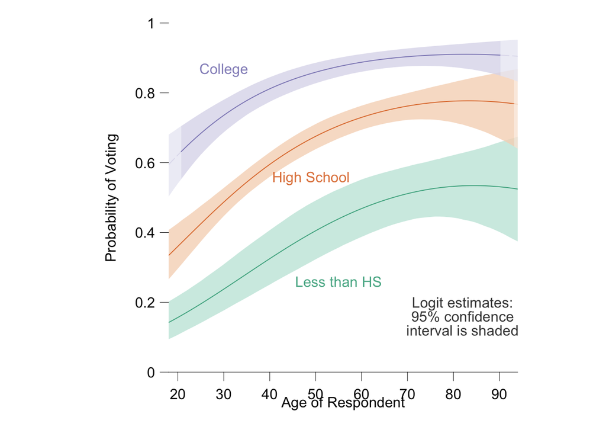

```r
# same thing for two other sets of sceneraios
hsSims <- logitsimev(hsScen, simbetas, ci=0.95)
collSims <- logitsimev(collScen, simbetas, ci=0.95)

# Get 3 nice colors for traces
col <- brewer.pal(3,"Dark2")

# Set up lineplot traces of expected probabilities

#Traces are elements of tile : lines, labels, legends...

# no hs
nohsTrace <- lineplot(x=xhyp, # age on x-axis
                      y=nohsSims$pe, #expected probability on y-axis
                      lower=nohsSims$lower, # lower confidence interval
                      upper=nohsSims$upper, #upper confidence interval
                      col=col[1], #color choice
                      extrapolate=list(data=mdata[,2:ncol(mdata)],
                                       #actual covariates (i.e., values in your data)
                               cfact=nohsScen$x[,2:ncol(hsScen$x)],#counterfactual covariates
                        omit.extrapolated=FALSE), #don't show extrapolated values
                      plot=1)

# hs but no college
hsTrace <- lineplot(x=xhyp,
                    y=hsSims$pe,
                    lower=hsSims$lower,
                    upper=hsSims$upper,
                    col=col[2],
                    extrapolate=list(data=mdata[,2:ncol(mdata)],
                                       cfact=hsScen$x[,2:ncol(hsScen$x)],
                                       omit.extrapolated=FALSE),
                    plot=1)

#college
collTrace <- lineplot(x=xhyp,
                      y=collSims$pe,
                      lower=collSims$lower,
                      upper=collSims$upper,
                      col=col[3],
                      extrapolate=list(data=mdata[,2:ncol(mdata)],
                                       cfact=collScen$x[,2:ncol(hsScen$x)],
                                       omit.extrapolated=FALSE),
                      plot=1)

# Set up traces with labels

labelTrace <- textTile(labels=c("Less than HS", "High School", "College"),
                       x=c( 55,    49,     30),
                       y=c( 0.26,  0.56,   0.87),
                       col=col,
                       plot=1)

# For legend

legendTrace <- textTile(labels=c("Logit estimates:", "95% confidence", "interval is shaded"),
                        x=c(82, 82, 82),
                        y=c(0.2, 0.16, 0.12),
                        plot=1)


#options(device="quartz")

# Plot traces using tile
voting<-tile(nohsTrace,
     hsTrace,
     collTrace,
     labelTrace,
     legendTrace,
     limits=c(18,94,0,1),
     xaxis=list(at=c(20,30,40,50,60,70,80,90)),
     yaxis=list(label.loc=-0.5, major=FALSE),
     xaxistitle=list(labels="Age of Respondent"),
     yaxistitle=list(labels="Probability of Voting"),
     width=list(null=5,yaxistitle=4,yaxis.labelspace=-0.5)
     #,output=list(file="educationEV",width=5.5)
)
```

# 4. Simulating first differences

[output not shown]

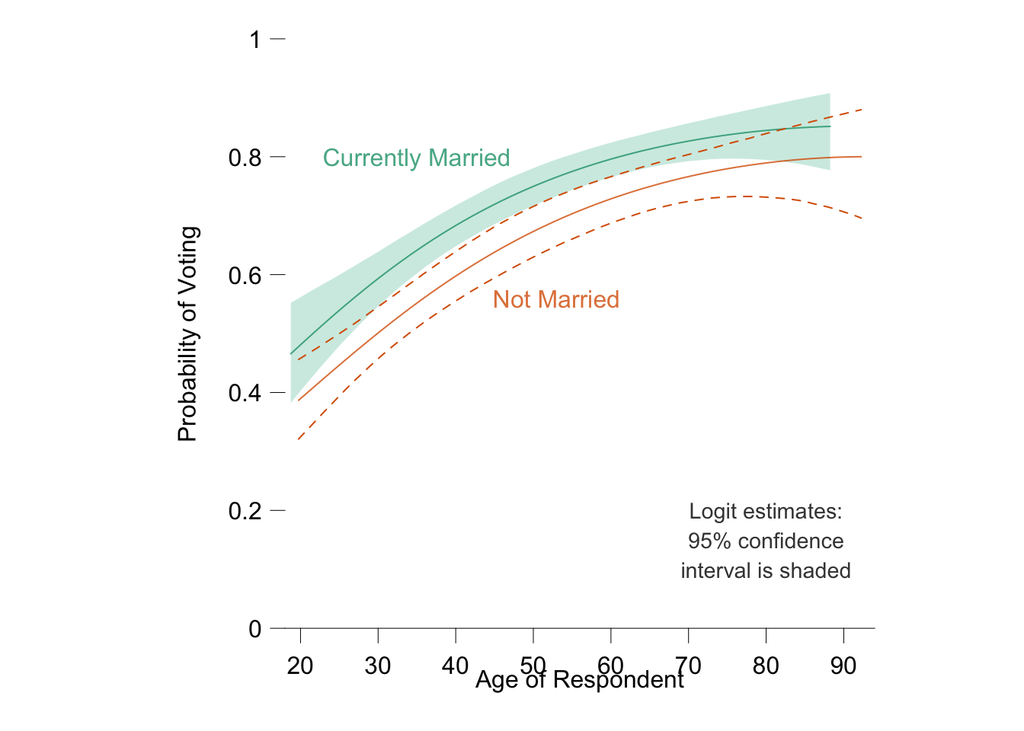

```r
################################################################
#
# Now consider a new specification adding the variable
# "ever married", or marriedo
#
# We will estimate this new model with glm(), then
# simulate new scenarios for marrieds and non-marrieds


# Estimate logit model using glm()


# Set up a new model formula and model specific data frame

model2 <- vote00 ~ age + I(age^2) + hsdeg + coldeg + marriedo
mdata2 <- extractdata(model2, data, na.rm=TRUE)

# Run logit & extract results
logit.m2 <- glm(model2, family=binomial, data=mdata2)
pe.m2 <- logit.m2$coefficients  # point estimates
vc.m2 <- vcov(logit.m2)         # var-cov matrix


# Simulate parameter distributions
sims <- 10000
simbetas.m2 <- mvrnorm(sims, pe.m2, vc.m2)


# Set up counterfactuals:  all ages

xhyp <- seq(18,97,1)
nscen <- length(xhyp)
marriedScen <- notmarrScen <- cfMake(model2, mdata2, nscen)
for (i in 1:nscen) {


  #  - we will use the marriedScen counterfactuals in FDs and RRs as well as EVs
  # Note below the careful use of before scenarios (xpre) and after scenarios (x)
  # :i.e., use of the same age range (18-97) for both x and xpre, only marriedo values differ.

  # Married (loop over each age)
  marriedScen <- cfChange(marriedScen, "age", x = xhyp[i], xpre= xhyp[i], scen = i)
  marriedScen <- cfChange(marriedScen, "marriedo", x = 1, xpre= 0, scen = i)

  # Not Married (loop over each age)
  notmarrScen <- cfChange(notmarrScen, "age", x = xhyp[i], scen = i)
  notmarrScen <- cfChange(notmarrScen, "marriedo", x = 0, scen = i)
}

# Simulate expected probabilities for all age scenarios for married and not married respectively
marriedSims <- logitsimev(marriedScen, simbetas.m2, ci=0.95)
notmarrSims <- logitsimev(notmarrScen, simbetas.m2, ci=0.95)

# Simulate first difference of voting wrt marriage: E(y|married)-E(y|notmarried)
marriedFD <- logitsimfd(marriedScen, simbetas.m2, ci=0.95)

# Simulate relative risk of voting wrt marriage: E(y|married)/E(y|notmarried)
marriedRR <- logitsimrr(marriedScen, simbetas.m2, ci=0.95)


## Make plots using tile

# Get 3 nice colors for traces
col <- brewer.pal(3,"Dark2")

# Set up lineplot traces of expected probabilities
marriedTrace <- lineplot(x=xhyp,
                         y=marriedSims$pe,
                         lower=marriedSims$lower,
                         upper=marriedSims$upper,
                         col=col[1],
                         extrapolate=list(data=mdata2[,2:ncol(mdata2)],
                                          cfact=marriedScen$x[,2:ncol(marriedScen$x)],
                                          omit.extrapolated=TRUE),
                         plot=1)

notmarrTrace <- lineplot(x=xhyp,
                         y=notmarrSims$pe,
                         lower=notmarrSims$lower,
                         upper=notmarrSims$upper,
                         col=col[2],
                         ci = list(mark="dashed"),
                         extrapolate=list(data=mdata2[,2:ncol(mdata2)],
                                          cfact=notmarrScen$x[,2:ncol(notmarrScen$x)],
                                          omit.extrapolated=TRUE),
                         plot=1)


# Set up traces with labels and legend
labelTrace <- textTile(labels=c("Currently Married", "Not Married"),
                       x=c( 35,    53),
                       y=c( 0.8,  0.56),
                       col=col,
                       plot=1)

legendTrace <- textTile(labels=c("Logit estimates:", "95% confidence", "interval is shaded"),
                        x=c(80, 80, 80),
                        y=c(0.2, 0.15, 0.10),
                        cex=0.9,
                        plot=1)

# Plot traces using tile
tile(marriedTrace,
     notmarrTrace,
     labelTrace,
     legendTrace,
     limits=c(18,94,0,1),
     xaxis=list(at=c(20,30,40,50,60,70,80,90)),
     yaxis=list(label.loc=-0.5, major=FALSE),
     xaxistitle=list(labels="Age of Respondent"),
     yaxistitle=list(labels="Probability of Voting"),
     width=list(null=5,yaxistitle=4,yaxis.labelspace=-0.5)
     #,output=list(file="marriedEV",width=5.5)
)
```

[output not shown]

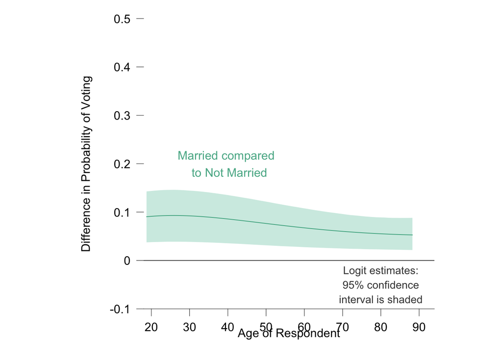

```r
# Plot First Difference

# Set up lineplot trace of first difference

marriedFDTrace <- lineplot(x=xhyp,
                           y=marriedFD$pe,
                           lower=marriedFD$lower,
                           upper=marriedFD$upper,
                           col=col[1],
                           extrapolate=list(data=mdata2[,2:ncol(mdata2)],
                                            cfact=marriedScen$x[,2:ncol(marriedScen$x)],
                                            omit.extrapolated=TRUE),
                           plot=1)


# Set up baseline: for first difference, this is 0
baseline <- linesTile(x=c(18,94),
                      y=c(0,0),
                      plot=1)

# Set up traces with labels and legend
labelFDTrace <- textTile(labels=c("Married compared \n to Not Married"),
                         x=c( 40),
                         y=c( 0.20),
                         col=col[1],
                         plot=1)

legendFDTrace <- textTile(labels=c("Logit estimates:", "95% confidence", "interval is shaded"),
                          x=c(80, 80, 80),
                          y=c(-0.02, -0.05, -0.08),
                          cex=0.9,
                          plot=1)

# Plot traces using tile
tile(marriedFDTrace,
     labelFDTrace,
     legendFDTrace,
     baseline,
     limits=c(18,94,-0.1,0.5),
     xaxis=list(at=c(20,30,40,50,60,70,80,90)),
     yaxis=list(label.loc=-0.5, major=FALSE),
     xaxistitle=list(labels="Age of Respondent"),
     yaxistitle=list(labels="Difference in Probability of Voting"),
     width=list(null=5,yaxistitle=4,yaxis.labelspace=-0.5)
     #,output=list(file="marriedFD",width=5.5)
)
```

[output not shown]

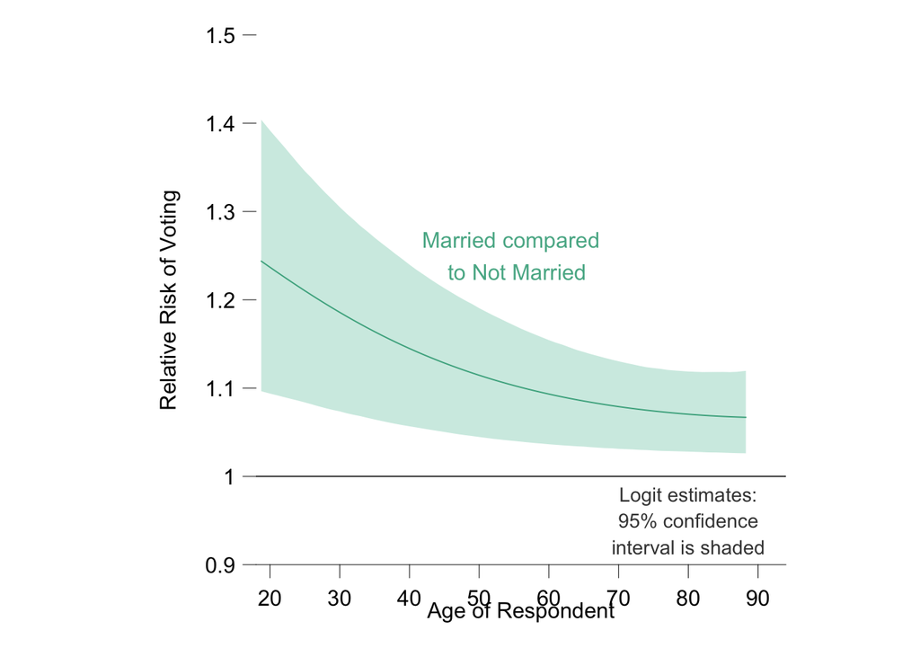

```r
# Plot Relative Risk

# Set up lineplot trace of relative risk
marriedRRTrace <- lineplot(x=xhyp,
                           y=marriedRR$pe,
                           lower=marriedRR$lower,
                           upper=marriedRR$upper,
                           col=col[1],
                           extrapolate=list(data=mdata2[,2:ncol(mdata2)],
                                            cfact=marriedScen$x[,2:ncol(marriedScen$x)],
                                            omit.extrapolated=TRUE),
                           plot=1)


# Set up baseline: for relative risk, this is 1

baseline <- linesTile(x=c(18,94),
                      y=c(1,1),
                      plot=1)

# Set up traces with labels and legend
labelRRTrace <- textTile(labels=c("Married compared \n to Not Married"),
                         x=c( 55),
                         y=c( 1.25),
                         col=col[1],
                         plot=1)

legendRRTrace <- textTile(labels=c("Logit estimates:", "95% confidence", "interval is shaded"),
                          x=c(80, 80, 80),
                          y=c(0.98, 0.95, 0.92),
                          cex=0.9,
                          plot=1)

# Plot traces using tile
tile(marriedRRTrace,
     labelRRTrace,
     legendRRTrace,
     baseline,
     limits=c(18,94,0.9,1.5),
     xaxis=list(at=c(20,30,40,50,60,70,80,90)),
     yaxis=list(label.loc=-0.5, major=FALSE),
     xaxistitle=list(labels="Age of Respondent"),
     yaxistitle=list(labels="Relative Risk of Voting"),
     width=list(null=5,yaxistitle=4,yaxis.labelspace=-0.5)
     #,output=list(file="marriedRR",width=5.5)
)
```